# Data Visualization Solutions

## 3.3.1 Aesthetic Mappings Exercises

1. What’s gone wrong with this code? Why are the points not blue?

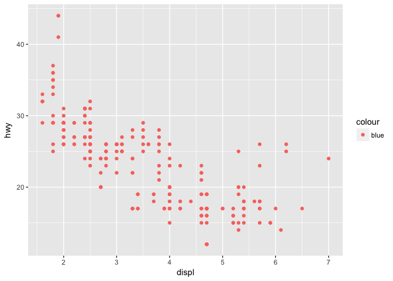

```r
ggplot(data = mpg) +
  geom_point(mapping = aes(x = displ, y = hwy, color = "blue"))
```

The problem is that color is mapped to an aesthetic. If we wanted to make the points blue, we would remove color from the aesthetic mapping.

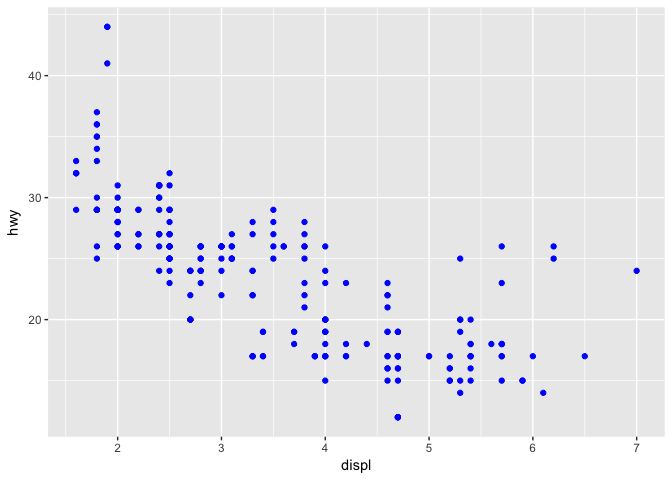

```r
ggplot(data = mpg) +
  geom_point(mapping = aes(x = displ, y = hwy), color = "blue")
```

2. Which variables in mpg are categorical? Which variables are continuous? (Hint: type ?mpg to read the documentation for the dataset). How can you see this information when you run mpg?

```r
str(mpg)
```

```
## Classes 'tbl_df', 'tbl' and 'data.frame':    234 obs. of  11 variables:
##  $ manufacturer: chr  "audi" "audi" "audi" "audi" ...
##  $ model       : chr  "a4" "a4" "a4" "a4" ...
##  $ displ       : num  1.8 1.8 2 2 2.8 2.8 3.1 1.8 1.8 2 ...
##  $ year        : int  1999 1999 2008 2008 1999 1999 2008 1999 1999 2008 ...
##  $ cyl         : int  4 4 4 4 6 6 6 4 4 4 ...
##  $ trans       : chr  "auto(l5)" "manual(m5)" "manual(m6)" "auto(av)" ...
##  $ drv         : chr  "f" "f" "f" "f" ...
##  $ cty         : int  18 21 20 21 16 18 18 18 16 20 ...
##  $ hwy         : int  29 29 31 30 26 26 27 26 25 28 ...
##  $ fl          : chr  "p" "p" "p" "p" ...
##  $ class       : chr  "compact" "compact" "compact" "compact" ...
```

`manufacturer`, `model`, `cyl`, `trans`, `drv`, `fl`, and `class` are categorical variables. `displ`, `year`, `cty` and `hwy` are continuous variables.

3. Map a continuous variable to color, size, and shape. How do these aesthetics behave differently for categorical vs. continuous variables?

A continuous variable cannot be mapped to shape. Mapping a continuous variable to color maps the points by a shaded spectrum. Mapping a continuous variable by size increases the size of the points depending on the value.

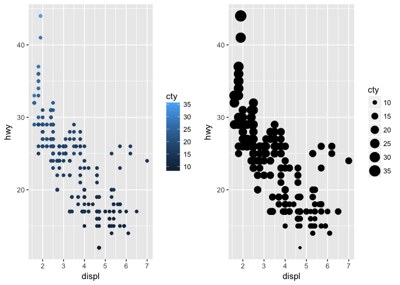

```r
# continuous variable mapped to color
p1 <- ggplot(mpg, aes(x = displ, y = hwy)) +
  geom_point(aes(color = cty))

# continuous variable mapped to size
p2 <- ggplot(mpg, aes(x = displ, y = hwy)) +
  geom_point(aes(size = cty))

grid.arrange(p1, p2, ncol = 2)
```

4. What happens if you map the same variable to multiple aesthetics?

There’s no inherent problem in mapping the same variable to multiple aesthetics. Here I’ve mapped `cyl` to both color and shape. But it would be confusing to the viewer.

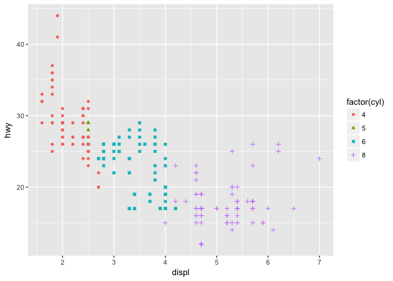

```r
ggplot(data = mpg) +
  geom_point(mapping = aes(x = displ, y = hwy,
                           color = factor(cyl), shape = factor(cyl)))
```

5. What does the stroke aesthetic do? What shapes does it work with? (Hint: use ?geom_point)

The stroke aesthetic modifies the width of the border of the point. It seems to work with all shapes.

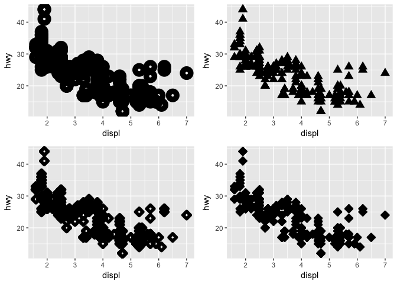

```r
p1 <- ggplot(data = mpg, aes(x = displ, y = hwy)) +
  geom_point(shape = 1, stroke = 5)

p2 <- ggplot(data = mpg, aes(x = displ, y = hwy)) +
  geom_point(shape = 17, stroke = 4)

p3 <- ggplot(data = mpg, aes(x = displ, y = hwy)) +
  geom_point(shape = 23, stroke = 3)

p4 <- ggplot(data = mpg, aes(x = displ, y = hwy)) +
  geom_point(shape = 9, stroke = 2)

grid.arrange(p1, p2, p3, p4, ncol = 2)
```

6. What happens if you map an aesthetic to something other than a variable name, like aes(colour = displ < 5)?

R colors the points according to the logical vector.

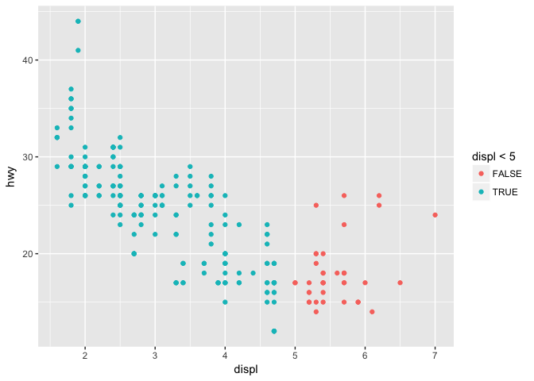

```r
ggplot(data = mpg, aes(x = displ, y = hwy)) +
  geom_point(aes(colour = displ < 5))
```

## 3.5.1 Facets Exercises

1. What happens if you facet on a continuous variable?

Faceting on a continuous variable will convert the variable to a factor variable and facet on all unique values as can be seen below.

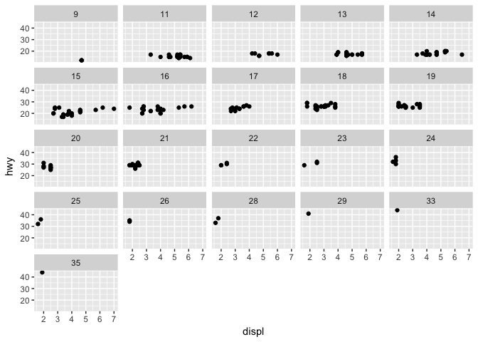

```r
ggplot(data = mpg) +
  geom_point(mapping = aes(x = displ, y = hwy)) +
  facet_wrap( ~ cty)
```

2. What do the empty cells in plot with facet_grid(drv ~ cyl) mean? How do they relate to this plot?

The empty cells in the plot below mean that there were no observations for those particular combinations of `drv` and `cyl`.

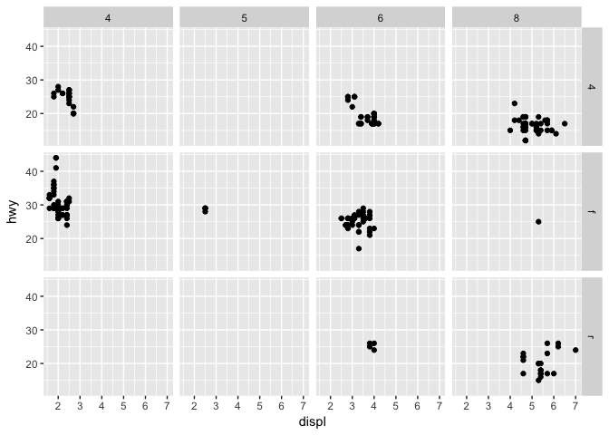

```r
ggplot(data = mpg) +
  geom_point(mapping = aes(x = displ, y = hwy)) +
  facet_grid(drv ~ cyl)
```

These empty plots correspond to the same combinations missing a point in the plot below.

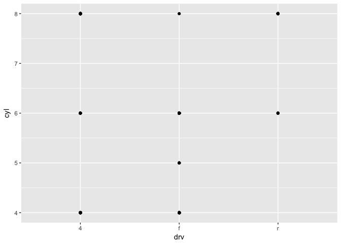

```r
ggplot(data = mpg) +
  geom_point(mapping = aes(x = drv, y = cyl))
```

3. What plots does the following code make? What does . do?

The first facets on `drv`, setting each level as a row. The second facets on `cyl`, setting each level as a column. The “.” is the stand-in for `facet_grid` when only one variable is called for faceting.

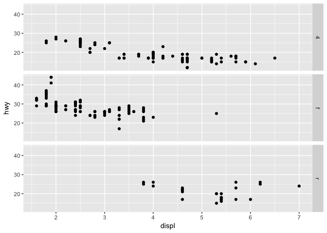

```r
ggplot(data = mpg) +
  geom_point(mapping = aes(x = displ, y = hwy)) +
  facet_grid(drv ~ .)
```

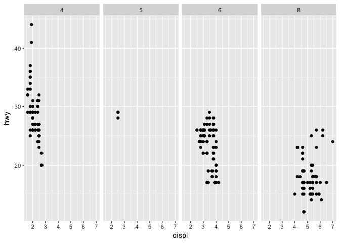

```r
ggplot(data = mpg) +
  geom_point(mapping = aes(x = displ, y = hwy)) +
  facet_grid(. ~ cyl)
```

4. Take the first faceted plot in this section:

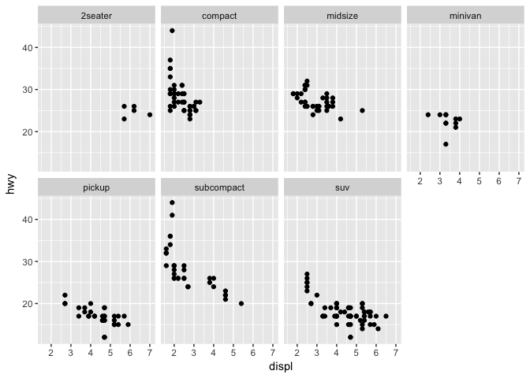

```r
ggplot(data = mpg) +
  geom_point(mapping = aes(x = displ, y = hwy)) +
  facet_wrap(~ class, nrow = 2)
```

What are the advantages to using faceting instead of the colour aesthetic? What are the disadvantages? How might the balance change if you had a larger dataset?

The advantages to faceting instead of using the colour aesthetic is being able to individually see each level on its own plot. This makes it easier to see the individual trend for each level without any overplotting or distraction. The disadvantage is that it becomes more difficult to compare levels to each other across subplots. As the dataset gets larger (more observations), facets might be a better choice to reduce overplotting. The number of levels is also important to determine if faceting is a good option. Having too many levels might force you to facet instead of filling by colour.

5. Read ?facet_wrap. What does nrow do? What does ncol do? What other options control the layout of the individual panels? Why doesn’t facet_grid() have nrow and ncol argument?

The `nrow` argument of `facet_wrap` lays out how many rows the facets should be plotted into. The `ncol` argument does the same for columns. So if there are 7 levels (as in the plot above), setting `nrow` to 2 means that there will be 4 columns.

6. When using facet_grid() you should usually put the variable with more unique levels in the columns. Why?

This decision boils down to what appears most visually simplistic and easier to scan across comparing rows or columns.